# Gapminder Multivariate Analysis

Ursula Neumann

March 2, 2018

## Introduction

On the Gapminder website I found three datasets, one for female BMI over time (“Body Mass Index (BMI), women, Kg/m2”), one for total cholesterol levels over time (“Cholesterol (fat) in blood, women, mmol/L”), and one for systolic blood pressure over time (Blood pressure (SBP), women, mmHg). These datasets are provided by the MRC-HPA Center for Environment and Health and span the years 1980 - 2008 for 199 countries. I previously performed an analysis of cholesterol vs BMI, but now want to add in the third parameter blood pressure. In addition, I would like to separate the data based on continent to see if any interesting observations can be made.

## Load datasets and prepare the dataframe for analysis

Below I have loaded all the datasets and transformed them into “tall” datasets using the gather function. Then I performed 3 sequential inner joins to produce a dataframe with the columns: country, continent, year, BMI, cholesterol and SBP. I’m unsure if there’s a way to streamline this process but it was simple enough.

```r
# Load the necessary libraries
library("tidyr")
library("dplyr")
```

```r
library("ggplot2")
library("gridExtra")
# Load the BMI dataset
df1 <- read.csv('female_BMI.csv', check.names = FALSE)
head(df1)
```

```
##               Country     1980     1981     1982     1983     1984
## 1         Afghanistan 20.44348 20.47765 20.52292 20.56493 20.60867
## 2             Albania 25.17427 25.19088 25.20032 25.21906 25.22359
## 3             Algeria 23.67764 23.80702 23.92626 24.03604 24.13630
## 4             Andorra 25.67324 25.69018 25.69922 25.70089 25.70584
## 5              Angola 20.06763 20.12766 20.19464 20.26439 20.34110
## 6 Antigua and Barbuda 24.22235 24.34043 24.43933 24.55735 24.70423
##       1985     1986     1987     1988     1989     1990     1991     1992
## 1 20.64796 20.68983 20.70902 20.71512 20.71421 20.70504 20.70117 20.67746
## 2 25.21257 25.20939 25.18918 25.16965 25.15370 25.13877 25.04670 24.96615
## 3 24.24213 24.33652 24.42523 24.50904 24.59436 24.67546 24.75504 24.84210
## 4 25.70877 25.71239 25.72437 25.74523 25.77649 25.81199 25.85168 25.87593
## 5 20.42624 20.51389 20.60929 20.70945 20.80873 20.91400 21.00432 21.08987
## 6 24.86193 25.02937 25.18394 25.35149 25.52673 25.67301 25.81131 25.95531
##       1993     1994     1995     1996     1997     1998     1999     2000
## 1 20.63639 20.59074 20.56750 20.55575 20.56759 20.59306 20.61717 20.61850
## 2 24.93558 24.93562 24.93706 24.96643 24.96754 25.00220 25.06254 25.12797
## 3 24.92523 24.99550 25.07258 25.15000 25.22635 25.30970 25.40139 25.49389
## 4 25.89671 25.91898 25.93933 25.96645 25.99661 26.03351 26.07432 26.10622
## 5 21.13495 21.18443 21.25985 21.36478 21.47863 21.60939 21.76054 21.91293
## 6 26.06340 26.15508 26.22408 26.29350 26.37160 26.44720 26.52800 26.61231
##       2001     2002     2003     2004     2005     2006     2007     2008
## 1 20.61353 20.65274 20.70828 20.76927 20.83858 20.91021 20.99060 21.07402
## 2 25.20332 25.27082 25.33198 25.39804 25.46525 25.53328 25.59394 25.65726
## 3 25.59477 25.69948 25.81168 25.93081 26.03886 26.15054 26.26096 26.36841
## 4 26.14707 26.19542 26.23892 26.28851 26.32247 26.36846 26.40095 26.43196
## 5 22.07646 22.26093 22.44571 22.63536 22.83412 23.04406 23.26330 23.48431
## 6 26.68539 26.76278 26.84799 26.96384 27.09834 27.23278 27.37364 27.50545
```

```r
# Gather the data into columns of country, year, and BMI
df_BMI <- gather(df1, key = "year", value = "BMI", 2:dim(df1)[2])
head(df_BMI)
```

```
##               Country year      BMI
## 1         Afghanistan 1980 20.44348
## 2             Albania 1980 25.17427
## 3             Algeria 1980 23.67764
## 4             Andorra 1980 25.67324
## 5              Angola 1980 20.06763
## 6 Antigua and Barbuda 1980 24.22235
```

```r
# Load the cholesterol dataset
df2 <- read.csv('female_cholesterol.csv', check.names = FALSE)
head(df2)
```

```
##   TC female (mmol/L), age standardized mean     1980     1981     1982
## 1                               Afghanistan 4.644476 4.637118 4.630770
## 2                                   Albania 5.039529 5.036610 5.033352
## 3                                   Algeria 4.976215 4.975257 4.974508
## 4                                   Andorra 6.132187 6.101291 6.069412
## 5                                    Angola 4.789354 4.769557 4.751330
## 6                       Antigua and Barbuda 5.013913 5.006714 5.000293
##       1983     1984     1985     1986     1987     1988     1989     1990
## 1 4.625318 4.619873 4.613289 4.607698 4.598080 4.583443 4.567768 4.548429
## 2 5.028138 5.022292 5.018456 5.012306 5.008334 5.002822 4.998255 4.991347
## 3 4.976556 4.976963 4.977419 4.974378 4.971097 4.963965 4.957217 4.951503
## 4 6.038793 6.008447 5.977998 5.948506 5.918512 5.890226 5.864313 5.836336
## 5 4.733550 4.719231 4.707431 4.693793 4.683528 4.674458 4.665655 4.654712
## 6 4.997209 4.996626 4.998084 5.001350 5.003486 5.008585 5.011400 5.014208
##       1991     1992     1993     1994     1995     1996     1997     1998
```

[output cut: 20 more lines]

```r
# Gather the data into columns of country, year, and cholesterol
df_chol <- gather(df2, key = "year", value = "cholesterol", 2:dim(df2)[2])
colnames(df_chol)[1] <- "Country"
head(df_chol)
```

```
##               Country year cholesterol
## 1         Afghanistan 1980    4.644476
## 2             Albania 1980    5.039529
## 3             Algeria 1980    4.976215
## 4             Andorra 1980    6.132187
## 5              Angola 1980    4.789354
## 6 Antigua and Barbuda 1980    5.013913
```

```r
# Load the blood pressure dataset
df3 <- read.csv('female_blood_pressure.csv', check.names = FALSE)
head(df3)
```

```
##   SBP female (mm Hg), age standardized mean     1980     1981     1982
## 1                               Afghanistan 122.0799 122.2677 122.4872
## 2                                   Albania 132.2048 132.1113 132.0324
## 3                                   Algeria 130.8334 130.9079 130.9790
## 4                                   Andorra 136.6040 135.9730 135.3111
## 5                                    Angola 130.0896 129.9897 129.8756
## 6                       Antigua and Barbuda 125.6712 125.6610 125.6315
##       1983     1984     1985     1986     1987     1988     1989     1990
## 1 122.7061 122.9095 123.0919 123.2892 123.4189 123.5137 123.5832 123.6358
## 2 131.9356 131.8073 131.6686 131.5425 131.3945 131.2248 131.0970 130.9075
## 3 131.0057 131.0516 131.0851 131.0921 131.0759 131.0466 131.0389 130.9832
## 4 134.6178 133.9310 133.2704 132.6709 132.1498 131.6667 131.2018 130.7709
## 5 129.7749 129.7096 129.6741 129.6562 129.6698 129.7407 129.8161 129.8817
## 6 125.6406 125.6806 125.6993 125.7380 125.7812 125.8496 125.8822 125.8859
##       1991     1992     1993     1994     1995     1996     1997     1998
```

[output cut: 20 more lines]

```r
# Gather the data into columns of country, year, and blood pressure
df_SBP <- gather(df3, key = "year", value = "SBP", 2:dim(df2)[2])
colnames(df_SBP)[1] <- "Country"
head(df_SBP)
```

```
##               Country year      SBP
## 1         Afghanistan 1980 122.0799
## 2             Albania 1980 132.2048
## 3             Algeria 1980 130.8334
## 4             Andorra 1980 136.6040
## 5              Angola 1980 130.0896
## 6 Antigua and Barbuda 1980 125.6712
```

```r
# Load the countries-continents dataset
df4 <- read.csv('countries_continents.csv', check.names = FALSE)
head(df4)
```

```
##    Country Continent
## 1  Algeria    Africa
## 2   Angola    Africa
## 3    Benin    Africa
## 4 Botswana    Africa
## 5  Burkina    Africa
## 6  Burundi    Africa
```

```r
# Join the BMI and cholesterol datasets using an inner join on country and year
df5 <- inner_join(df_BMI, df_chol, by = c("Country", "year"))
head(df5)
```

```
##               Country year      BMI cholesterol
## 1         Afghanistan 1980 20.44348    4.644476
## 2             Albania 1980 25.17427    5.039529
## 3             Algeria 1980 23.67764    4.976215
## 4             Andorra 1980 25.67324    6.132187
## 5              Angola 1980 20.06763    4.789354
## 6 Antigua and Barbuda 1980 24.22235    5.013913
```

```r
# Join the blood pressure dataset using an inner join on country and year
df6 <- inner_join(df5, df_SBP, by = c("Country", "year"))
head(df6)
```

```
##               Country year      BMI cholesterol      SBP
## 1         Afghanistan 1980 20.44348    4.644476 122.0799
## 2             Albania 1980 25.17427    5.039529 132.2048
## 3             Algeria 1980 23.67764    4.976215 130.8334
## 4             Andorra 1980 25.67324    6.132187 136.6040
## 5              Angola 1980 20.06763    4.789354 130.0896
## 6 Antigua and Barbuda 1980 24.22235    5.013913 125.6712
```

```r
# Join in the countires_continents dataset
df <- inner_join(df6, df4, by = c("Country"))
head(df)
```

```
##               Country year      BMI cholesterol      SBP     Continent
## 1         Afghanistan 1980 20.44348    4.644476 122.0799          Asia
## 2             Albania 1980 25.17427    5.039529 132.2048        Europe
## 3             Algeria 1980 23.67764    4.976215 130.8334        Africa
## 4             Andorra 1980 25.67324    6.132187 136.6040        Europe
## 5              Angola 1980 20.06763    4.789354 130.0896        Africa
## 6 Antigua and Barbuda 1980 24.22235    5.013913 125.6712 North America
```

```r
# Reorder the columns
df <- df[c(1,6, 2, 3, 4, 5)]
head(df)
```

```
##               Country     Continent year      BMI cholesterol      SBP
## 1         Afghanistan          Asia 1980 20.44348    4.644476 122.0799
## 2             Albania        Europe 1980 25.17427    5.039529 132.2048
## 3             Algeria        Africa 1980 23.67764    4.976215 130.8334
## 4             Andorra        Europe 1980 25.67324    6.132187 136.6040
## 5              Angola        Africa 1980 20.06763    4.789354 130.0896
## 6 Antigua and Barbuda North America 1980 24.22235    5.013913 125.6712
```

```r
# Change the year variable to a numeric class
df$year <- as.numeric(df$year)
```

## Previous analysis: Cholesterol vs BMI

As shown below there is a moderately strong positive correlation (r = 0.51) between cholesterol and BMI.

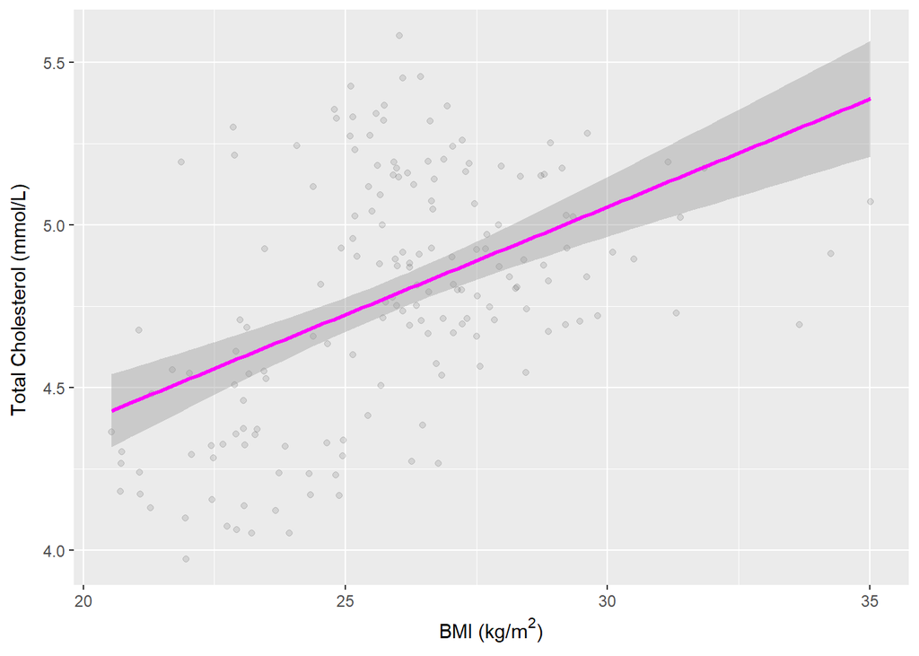

```r
# Graph a scatterplot of cholesterol vs BMI in 2008 for all countries
ggplot(aes(x = BMI,
           y = cholesterol),
       data = subset(df, df$year == 2008)) +
  geom_point(alpha = 1/10) +
  geom_smooth(method = 'lm', color = 'magenta') +
  labs(x = expression(paste("BMI (kg/m"^2, ")")),
       y = expression(paste("Total Cholesterol (mmol/L)")))
```

## Cholesterol vs BMI, colored by continent, point size by SBP

To add more information/variables to the graph above, I decided to color the points by continent, and size the points by blood pressure. Below is a plot with all countries on one graph, as well as a plot where the points faceted by continent to be able to better view each cluster. Africa and Asia have the most widespread BMI and cholesterol levels. The BMIs of Europe, North America, and South America are more clustered in the middle of the graph. I expected that the countries with the highest blood pressure would be those at the top right corner of the graph (high cholesterol and high BMI). However, the largest points are those clustered at the bottom left corner of the graph, from African countries.

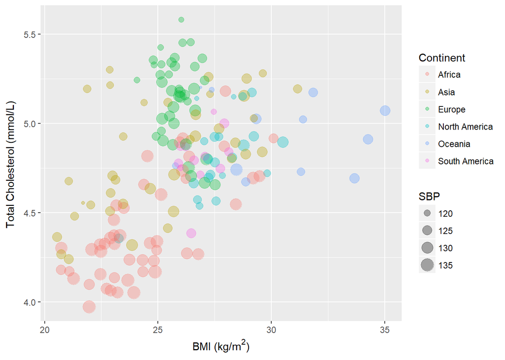

```r
ggplot(aes(x = BMI,
           y = cholesterol),
       data = subset(df, df$year == 2008)) +
  geom_point(alpha = 1/3, aes(color = Continent, size = SBP)) +
  labs(x = expression(paste("BMI (kg/m"^2, ")")),
       y = expression(paste("Total Cholesterol (mmol/L)")))
```

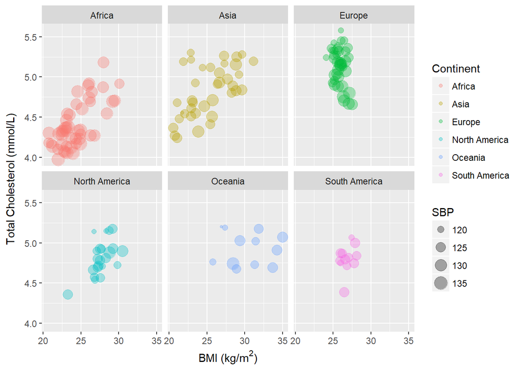

```r
ggplot(aes(x = BMI,
           y = cholesterol),
       data = subset(df, df$year == 2008)) +
  geom_point(alpha = 1/3, aes(color = Continent, size = SBP)) +
  labs(x = expression(paste("BMI (kg/m"^2, ")")),
       y = expression(paste("Total Cholesterol (mmol/L)")))+
  facet_wrap(~Continent)
```

## Resources

1. https://www.gapminder.org/data/
2. https://old.datahub.io/dataset/countries-continents/resource/aa08c34c-57e8-4e15-bd36-969bee26aba5